# Final project

Pranandita & Risolat

08/01/2024

```r
data <- read_excel("New_DATA.xlsx")
```

### Correlation matrix

**Linear variables:**

```r
corr_data <- select(data, fdi, ps, gdp, gdp_g, cpi, t_o)
corr_data <- na.omit(corr_data)

corr_matrix <- cor(corr_data)
kable(corr_matrix, format = "html", caption = "Correlation matrix") %>%
  kable_styling(full_width = FALSE)
```

Correlation matrix

|  | fdi | ps | gdp | gdp_g | cpi | t_o |
| --- | --- | --- | --- | --- | --- | --- |
| fdi | 1.0000000 | 0.1888249 | 0.0298872 | -0.1587646 | -0.0917051 | 0.2504540 |
| ps | 0.1888249 | 1.0000000 | -0.3949439 | -0.3110049 | -0.2537213 | 0.6082961 |
| gdp | 0.0298872 | -0.3949439 | 1.0000000 | 0.0170886 | 0.1274845 | -0.1634856 |
| gdp_g | -0.1587646 | -0.3110049 | 0.0170886 | 1.0000000 | 0.4194796 | -0.0183543 |
| cpi | -0.0917051 | -0.2537213 | 0.1274845 | 0.4194796 | 1.0000000 | -0.2062893 |
| t_o | 0.2504540 | 0.6082961 | -0.1634856 | -0.0183543 | -0.2062893 | 1.0000000 |

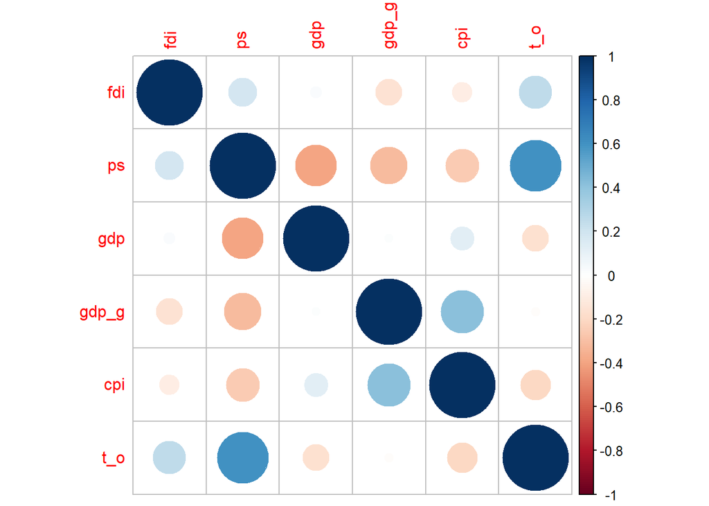

```r
corrplot(corr_matrix)
```

**With log(FDI) and log(GDP):**

```r
corr_data <- corr_data %>%
  mutate(log_fdi = log(fdi), log_gdp = log(gdp)) %>%
  select(-fdi, -gdp)
corr_data <- na.omit(corr_data)

corr_matrix <- cor(corr_data)
kable(corr_matrix, format = "html", caption = "Correlation matrix") %>%
  kable_styling(full_width = FALSE)
```

Correlation matrix

|  | ps | gdp_g | cpi | t_o | log_fdi | log_gdp |
| --- | --- | --- | --- | --- | --- | --- |
| ps | 1.0000000 | -0.2825768 | -0.2401083 | 0.6231892 | 0.1041936 | -0.3796711 |
| gdp_g | -0.2825768 | 1.0000000 | 0.4038945 | -0.0366072 | 0.0499453 | 0.0460140 |
| cpi | -0.2401083 | 0.4038945 | 1.0000000 | -0.2146668 | 0.0007179 | 0.1022178 |
| t_o | 0.6231892 | -0.0366072 | -0.2146668 | 1.0000000 | 0.5311591 | 0.0725998 |
| log_fdi | 0.1041936 | 0.0499453 | 0.0007179 | 0.5311591 | 1.0000000 | 0.7007123 |
| log_gdp | -0.3796711 | 0.0460140 | 0.1022178 | 0.0725998 | 0.7007123 | 1.0000000 |

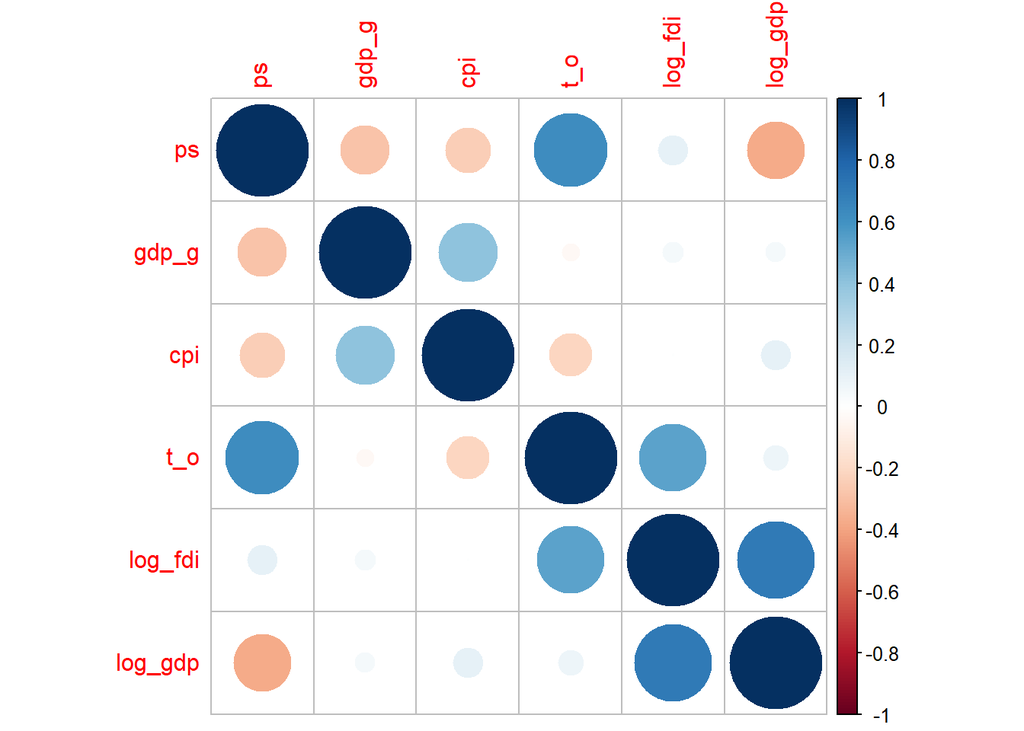

```r
corrplot(corr_matrix)
```

### Regressions

Here, we present separately the regressions of FDI on political stability with real GDP, growth rate, CPI, and trade openness as controls. We use log of FDI and real GDP; all other variables are linear.

We add the independent and control variables one by one to the model and then perform pooled OLS and random and fixed effects regressions for each set of variables. For each, we perform the BPLM test (`pFtest`) to check for panel effects. Next, we perform the Hausman test (`phtest`) to decide between fixed and random effects models.

The results are summarized separately for each set of models along with significance levels of all test statistics.

```r
## only political stability

# pooled OLS
pols1 = lm(log(fdi) ~ ps, data = data)

# fixed effects
f1 <- plm(log(fdi) ~ ps, index = c("country", "year"), data = data, model = "within")

#random effects
r1 <- plm(log(fdi) ~ ps, index = c("country", "year"), data = data, model = "random")

# Hausman test
h1_stat <- round(phtest(f1, r1)$statistic, 2)
h1_p <- round(phtest(f1, r1)$p.value, 4)

# Breusch-Pagan LM test
bplm1_stat <- round(pFtest(f1, pols1)$statistic, 2)
bplm1_p <- sprintf("%.2e", pFtest(f1, pols1)$p.value)

# Regression output #1

stargazer(pols1, f1, r1,
          title="Regressions on FDI - only political stability (independent variable)",
          type="html",
          header=FALSE,
          report = "vc*s",
          dep.var.labels = c("FDI"),
          column.labels = c("Pooled OLS", "Fixed effects", "Random effects"),
          covariate.labels = c("Intercept", "Political stability"),
          add.lines = list(
            c("BPLM (FE)", "", "", ""),
            c("statistic", bplm1_stat, "", ""),
            c("p-value", bplm1_p, "", ""),
            c("Hausman", "", "", ""),
            c("statistic", h1_stat, "", ""),
            c("p-value", h1_p, "", "")
          ),
          intercept.bottom = F,
          digits = 2,
          notes.align = "l",
          notes = c("Dataset: World Bank Database", "lm() functions"))
```

**Regressions on FDI - only political stability (independent variable)**

|  | *Dependent variable:* |  |  |
| --- | --- | --- | --- |
|  | FDI |  |  |
|  | *OLS* | *panel* |  |
|  |  | *linear* |  |
|  | Pooled OLS | Fixed effects | Random effects |
|  | (1) | (2) | (3) |
| Intercept | 22.52*** |  | 22.48*** |
|  | (0.19) |  | (0.60) |
| Political stability | 0.17 | 0.83 | 0.60 |
|  | (0.23) | (0.50) | (0.41) |
| BPLM (FE) |  |  |  |
| statistic | 34.64 |  |  |
| p-value | 8.41e-23 |  |  |
| Hausman |  |  |  |
| statistic | 0.69 |  |  |
| p-value | 0.407 |  |  |
| Observations | 89 | 89 | 89 |
| R<sup>2</sup> | 0.01 | 0.03 | 0.01 |
| Adjusted R<sup>2</sup> | -0.01 | -0.08 | 0.001 |
| Residual Std. Error | 1.84 (df = 87) |  |  |
| F Statistic | 0.52 (df = 1; 87) | 2.75 (df = 1; 79) | 2.08 |
| *Note:* | p<0.1; p<0.05; p<0.01 |  |  |
|  | Dataset: World Bank Database |  |  |
|  | lm() functions |  |  |

```r
## political stability + gdp as control

# pooled OLS
pols2 = lm(log(fdi) ~ ps + log(gdp), data = data)

# fixed effects
f2 <- plm(log(fdi) ~ ps + log(gdp), index = c("country", "year"), data = data, model = "within")

#random effects
r2 <- plm(log(fdi) ~ ps + log(gdp), index = c("country", "year"), data = data, model = "random")

# Hausman test
h2_stat <- round(phtest(f2, r2)$statistic, 2)
h2_p <- round(phtest(f2, r2)$p.value, 4)

# Breusch-Pagan LM test
bplm2_stat <- round(pFtest(f2, pols2)$statistic, 2)
bplm2_p <- sprintf("%.2e", pFtest(f2, pols2)$p.value)

# Regression output #2

stargazer(pols2, f2, r2,
          title="Regressions on FDI - political stability (independent variable) + real GDP as control",
          type="html",
          header=FALSE,
          report = "vc*s",
          dep.var.labels = c("FDI"),
          column.labels = c("Pooled OLS", "Fixed effects", "Random effects"),
          covariate.labels = c("Intercept", "Political stability", "Log(GDP)"),
          add.lines = list(
            c("BPLM (FE)", "", "", ""),
            c("statistic", bplm2_stat, "", ""),
            c("p-value", bplm2_p, "", ""),
            c("Hausman", "", "", ""),
            c("statistic", h2_stat, "", ""),
            c("p-value", h2_p, "", "")
          ),
          intercept.bottom = F,
          digits = 2,
          notes.align = "l",
          notes = c("Dataset: World Bank Database", "lm() functions"))
```

**Regressions on FDI - political stability (independent variable) + real GDP as control**

|  | *Dependent variable:* |  |  |
| --- | --- | --- | --- |
|  | FDI |  |  |
|  | *OLS* | *panel* |  |
|  |  | *linear* |  |
|  | Pooled OLS | Fixed effects | Random effects |
|  | (1) | (2) | (3) |
| Intercept | -4.14** |  | -4.37 |
|  | (2.06) |  | (4.44) |
| Political stability | 0.93*** | -0.13 | 0.76*** |
|  | (0.15) | (0.57) | (0.28) |
| Log(GDP) | 1.04*** | 2.16*** | 1.05*** |
|  | (0.08) | (0.72) | (0.17) |
| BPLM (FE) |  |  |  |
| statistic | 6.86 |  |  |
| p-value | 8.54e-07 |  |  |
| Hausman |  |  |  |
| statistic | 3.45 |  |  |
| p-value | 0.1781 |  |  |
| Observations | 89 | 89 | 89 |
| R<sup>2</sup> | 0.66 | 0.13 | 0.27 |
| Adjusted R<sup>2</sup> | 0.66 | 0.02 | 0.25 |
| Residual Std. Error | 1.07 (df = 86) |  |  |
| F Statistic | 84.78*** (df = 2; 86) | 6.05*** (df = 2; 78) | 38.23*** |
| *Note:* | p<0.1; p<0.05; p<0.01 |  |  |
|  | Dataset: World Bank Database |  |  |
|  | lm() functions |  |  |

```r
## political stability + gdp, growth as controls

# pooled OLS
pols3 = lm(log(fdi) ~ ps + log(gdp) + gdp_g, data = data)

# fixed effects
f3 <- plm(log(fdi) ~ ps + log(gdp) + gdp_g, index = c("country", "year"), data = data, model = "within")

#random effects
r3 <- plm(log(fdi) ~ ps + log(gdp) + gdp_g, index = c("country", "year"), data = data, model = "random")

# Hausman test
h3_stat <- round(phtest(f3, r3)$statistic, 2)
h3_p <- round(phtest(f3, r3)$p.value, 4)

# Breusch-Pagan LM test
bplm3_stat <- round(pFtest(f3, pols3)$statistic, 2)
bplm3_p <- sprintf("%.2e", pFtest(f3, pols3)$p.value)

# Regression output #3

stargazer(pols3, f3, r3,
          title="Regressions on FDI - political stability (independent variable) + real GDP and growth rate as controls",
          type="html",
          header=FALSE,
          report = "vc*s",
          dep.var.labels = c("FDI"),
          column.labels = c("Pooled OLS", "Fixed effects", "Random effects"),
          covariate.labels = c("Intercept", "Political stability", "Log(GDP)", "Growth rate"),
          add.lines = list(
            c("BPLM (FE)", "", "", ""),
            c("statistic", bplm3_stat, "", ""),
            c("p-value", bplm3_p, "", ""),
            c("Hausman", "", "", ""),
            c("statistic", h3_stat, "", ""),
            c("p-value", h3_p, "", "")
          ),
          intercept.bottom = F,
          digits = 2,
          notes.align = "l",
          notes = c("Dataset: World Bank Database", "lm() functions"))
```

**Regressions on FDI - political stability (independent variable) + real GDP and growth rate as controls**

|  | *Dependent variable:* |  |  |
| --- | --- | --- | --- |
|  | FDI |  |  |
|  | *OLS* | *panel* |  |
|  |  | *linear* |  |
|  | Pooled OLS | Fixed effects | Random effects |
|  | (1) | (2) | (3) |
| Intercept | -5.14** |  | -4.25 |
|  | (2.06) |  | (4.06) |
| Political stability | 1.03*** | -0.24 | 0.79*** |
|  | (0.15) | (0.59) | (0.27) |
| Log(GDP) | 1.06*** | 2.12*** | 1.05*** |
|  | (0.08) | (0.72) | (0.16) |
| Growth rate | 0.10** | -0.05 | -0.001 |
|  | (0.05) | (0.06) | (0.05) |
| BPLM (FE) |  |  |  |
| statistic | 6.04 |  |  |
| p-value | 5.15e-06 |  |  |
| Hausman |  |  |  |
| statistic | 8.82 |  |  |
| p-value | 0.0318 |  |  |
| Observations | 89 | 89 | 89 |
| R<sup>2</sup> | 0.68 | 0.14 | 0.31 |
| Adjusted R<sup>2</sup> | 0.67 | 0.02 | 0.29 |
| Residual Std. Error | 1.05 (df = 85) |  |  |
| F Statistic | 60.75*** (df = 3; 85) | 4.30*** (df = 3; 77) | 46.15*** |
| *Note:* | p<0.1; p<0.05; p<0.01 |  |  |
|  | Dataset: World Bank Database |  |  |
|  | lm() functions |  |  |

```r
## political stability + gdp, growth, cpi as controls

# pooled OLS
pols4 = lm(log(fdi) ~ ps + log(gdp) + gdp_g + cpi, data = data)

# fixed effects
f4 <- plm(log(fdi) ~ ps + log(gdp) + gdp_g + cpi, index = c("country", "year"), data = data, model = "within")

#random effects
r4 <- plm(log(fdi) ~ ps + log(gdp) + gdp_g + cpi, index = c("country", "year"), data = data, model = "random")

# Hausman test
h4_stat <- round(phtest(f4, r4)$statistic, 2)
h4_p <- round(phtest(f4, r4)$p.value, 4)

# Breusch-Pagan LM test
bplm4_stat <- round(pFtest(f4, pols4)$statistic, 2)
bplm4_p <- sprintf("%.2e", pFtest(f4, pols4)$p.value)

stargazer(pols1, f4, r4,
          title="Regressions on FDI - political stability (independent variable) + real GDP, growth, and CPI as controls",
          type="html",
          header=FALSE,
          report = "vc*s",
          dep.var.labels = c("FDI"),
          column.labels = c("Pooled OLS", "Fixed effects", "Random effects"),
          covariate.labels = c("Intercept", "Political stability", "Log(GDP)", "Growth rate", "CPI"),
          add.lines = list(
            c("BPLM (FE)", "", "", ""),
            c("statistic", bplm4_stat, "", ""),
            c("p-value", bplm4_p, "", ""),
            c("Hausman", "", "", ""),
            c("statistic", h4_stat, "", ""),
            c("p-value", h4_p, "", "")
          ),
          intercept.bottom = F,
          digits = 2,
          notes.align = "l",
          notes = c("Dataset: World Bank Database", "lm() functions"))
```

**Regressions on FDI - political stability (independent variable) + real GDP, growth, and CPI as controls**

|  | *Dependent variable:* |  |  |
| --- | --- | --- | --- |
|  | FDI |  |  |
|  | *OLS* | *panel* |  |
|  |  | *linear* |  |
|  | Pooled OLS | Fixed effects | Random effects |
|  | (1) | (2) | (3) |
| Intercept | 22.52*** |  | -4.14 |
|  | (0.19) |  | (3.90) |
| Political stability | 0.17 | -0.25 | 0.80*** |
|  | (0.23) | (0.59) | (0.27) |
| Log(GDP) |  | 2.14** | 1.04*** |
|  |  | (0.84) | (0.15) |
| Growth rate |  | -0.05 | 0.01 |
|  |  | (0.06) | (0.05) |
| CPI |  | 0.003 | -0.02 |
|  |  | (0.05) | (0.04) |
| BPLM (FE) |  |  |  |
| statistic | 5.9 |  |  |
| p-value | 7.29e-06 |  |  |
| Hausman |  |  |  |
| statistic | 4.35 |  |  |
| p-value | 0.3612 |  |  |
| Observations | 89 | 89 | 89 |
| R<sup>2</sup> | 0.01 | 0.14 | 0.33 |
| Adjusted R<sup>2</sup> | -0.01 | 0.01 | 0.30 |
| Residual Std. Error | 1.84 (df = 87) |  |  |
| F Statistic | 0.52 (df = 1; 87) | 3.18** (df = 4; 76) | 50.43*** |
| *Note:* | p<0.1; p<0.05; p<0.01 |  |  |
|  | Dataset: World Bank Database |  |  |
|  | lm() functions |  |  |

```r
## political stability + gdp, growth, cpi, trade openness as controls

# pooled OLS
pols5 = lm(log(fdi) ~ ps + log(gdp) + gdp_g + cpi + t_o, data = data)

# fixed effects
f5 <- plm(log(fdi) ~ ps + log(gdp) + gdp_g + cpi + t_o, index = c("country", "year"), data = data, model = "within")

#random effects
r5 <- plm(log(fdi) ~ ps + log(gdp) + gdp_g + cpi + t_o, index = c("country", "year"), data = data, model = "random")

# Hausman test
h5_stat <- round(phtest(f5, r5)$statistic, 2)
h5_p <- round(phtest(f5, r5)$p.value, 4)

# Breusch-Pagan LM test
bplm5_stat <- round(pFtest(f5, pols5)$statistic, 2)
bplm5_p <- round(pFtest(f5, pols5)$p.value, 4)

# Regression output #5

stargazer(pols5, f5, r5,
          title="Regressions on FDI - political stability (independent variable) + real GDP, growth, CPI, and trade openness as controls",
          type="html",
          header=FALSE,
          report = "vc*s",
          dep.var.labels = c("FDI"),
          column.labels = c("Pooled OLS", "Fixed effects", "Random effects"),
          covariate.labels = c("Intercept", "Political stability", "Log(GDP)", "Growth rate", "CPI", "Trade openness"),
          add.lines = list(
            c("BPLM (FE)", "", "", ""),
            c("statistic", bplm5_stat, "", ""),
            c("p-value", bplm5_p, "", ""),
            c("Hausman", "", "", ""),
            c("statistic", h5_stat, "", ""),
            c("p-value", h5_p, "", "")
          ),
          intercept.bottom = F,
          digits = 2,
          notes.align = "l",
          notes = c("Dataset: World Bank Database", "lm() functions"))
```

**Regressions on FDI - political stability (independent variable) + real GDP, growth, CPI, and trade openness as controls**

|  | *Dependent variable:* |  |  |
| --- | --- | --- | --- |
|  | FDI |  |  |
|  | *OLS* | *panel* |  |
|  |  | *linear* |  |
|  | Pooled OLS | Fixed effects | Random effects |
|  | (1) | (2) | (3) |
| Intercept | -1.43 |  | -1.98 |
|  | (2.14) |  | (3.08) |
| Political stability | 0.37* | -0.27 | 0.40 |
|  | (0.21) | (0.62) | (0.28) |
| Log(GDP) | 0.88*** | 2.21** | 0.92*** |
|  | (0.09) | (0.89) | (0.12) |
| Growth rate | 0.05 | -0.05 | 0.005 |
|  | (0.05) | (0.06) | (0.05) |
| CPI | 0.01 | 0.01 | -0.01 |
|  | (0.04) | (0.05) | (0.04) |
| Trade openness | 0.01*** | -0.004 | 0.01*** |
|  | (0.002) | (0.01) | (0.003) |
| BPLM (FE) |  |  |  |
| statistic | 2.79 |  |  |
| p-value | 0.0096 |  |  |
| Hausman |  |  |  |
| statistic | 10.57 |  |  |
| p-value | 0.0606 |  |  |
| Observations | 85 | 85 | 85 |
| R<sup>2</sup> | 0.74 | 0.14 | 0.44 |
| Adjusted R<sup>2</sup> | 0.72 | -0.02 | 0.40 |
| Residual Std. Error | 0.97 (df = 79) |  |  |
| F Statistic | 44.02*** (df = 5; 79) | 2.24* (df = 5; 71) | 96.91*** |
| *Note:* | p<0.1; p<0.05; p<0.01 |  |  |
|  | Dataset: World Bank Database |  |  |
|  | lm() functions |  |  |

### Final results

```r
stargazer(r1, r2, f3, r4, f5,
          title="Final models",
          type="html",
          header=FALSE,
          report = "vc*s",
          dep.var.labels = c("FDI"),
          column.labels = c("Model #1", "Model #2", "Model #3", "Model #4", "Model #5"),
          covariate.labels = c("Intercept", "Political stability", "Log(GDP)", "Growth rate", "CPI", "Trade openness"),
          add.lines = list(
            c("", "Random", "Random", "Fixed", "Random", "Fixed"),
            c("BPLM", paste(as.character(bplm1_stat),"***"), paste(as.character(bplm2_stat),"***"), paste(as.character(bplm3_stat),"***"), paste(as.character(bplm4_stat),"***"), paste(as.character(bplm5_stat),"**")),
            c("Hausman", h1_stat, h2_stat, paste(as.character(h3_stat),"**"), h4_stat, paste(as.character(h5_stat),"**"))
          ),
          intercept.bottom = F,
          digits = 2,
          notes.align = "l",
          notes = c("Dataset: World Bank Database", "lm() functions"))
```

**Final models**

[output not shown]

### Testing assumptions

We test here the Gauss-Markov assumptions for the selected model: Model #4 (`log(fdi) ~ ps + log(gdp) + gdp_g + cpi`).

```r
## BPLM
bp <- bptest(f4)
bp_stat <- round(bptest(f4)$statistic, 2)
bp_p <- round(bptest(f4)$p.value, 4)

## Wooldridge test
wooldridge <- pbgtest(f4)
wooldridge_stat <- round(pbgtest(f4)$statistic, 2)
wooldridge_p <- round(pbgtest(f4)$p.value, 4)
```

The following table presents the results of tests performed to verify assumptions.

```r
assumptions_table <- data.frame(
  Assumption = c("Homoskedasticity", "No autocorrelation", "Exogeneity", "No spherical errors"),
  Test = c("Breusch-Pagan Lagrangian multipliers", "Wooldridge serial correlation", "Hausman", "Breusch-Pagan Lagrangian multipliers"),
  Statistic = c(bp_stat, wooldridge_stat, h4_stat, bp_stat),
  p = c(bp_p, wooldridge_p, h4_p, bp_p),
  Satisfied = c("Yes", "Yes", "Yes", "Yes")
)

assumptions_table %>%
  kable(caption = "Gauss--Markov assumption tests") %>%
  kable_classic(full_width = F, html_font = "Cambria")
```

Gauss–Markov assumption tests

| Assumption | Test | Statistic | p | Satisfied |
| --- | --- | --- | --- | --- |
| Homoskedasticity | Breusch-Pagan Lagrangian multipliers | 6.11 | 0.1909 | Yes |
| No autocorrelation | Wooldridge serial correlation | 14.07 | 0.1197 | Yes |
| Exogeneity | Hausman | 4.35 | 0.3612 | Yes |
| No spherical errors | Breusch-Pagan Lagrangian multipliers | 6.11 | 0.1909 | Yes |

As none of the test statistics are signficant, we conclude that the assumptions are satisfied.

To test for the no multicollinearity assumption, we create the correlation matrix of the coefficients of the regression.

```r
## Multicollinearity: Correlation matrix
correlation_matrix <- cor(f4$model[, -1])
kable(correlation_matrix, format = "markdown")
```

|  | ps | log(gdp) | gdp_g | cpi |
| --- | --- | --- | --- | --- |
| ps | 1.0000000 | -0.3946004 | -0.2682864 | -0.2454229 |
| log(gdp) | -0.3946004 | 1.0000000 | 0.0168582 | 0.1197693 |
| gdp_g | -0.2682864 | 0.0168582 | 1.0000000 | 0.3886808 |
| cpi | -0.2454229 | 0.1197693 | 0.3886808 | 1.0000000 |

As none of the coefficients are $>|0.6|$, we conclude that there are no significant multicollinearities that may affect our results.